# Shark Capture

Project 2

500470426

University of Sydney | MATH1005 | November 2020

# 1 Executive Summary

# 2 Initial Data Analysis (IDA)

This report is based on the Shark Control Program Catch Statistics which examines the types of sharks caught within QLD in 2016. This data was sourced directly from the Queensland government - Agriculture and Fisheries Division making these sources both official and reliable. The variables identified within the report are the amount of sharks caught, the area in which they were caught in and their species. The assumption here is that the amount of sharks caught is directly related to the concentration of sharks in that area.

The potential stakeholders for this data include Marine-Life (Shark) conservatists who need to uncover areas where shark concentrations are high and safeguard them. These can include potential breeding spots and uncover migrating patterns. Additionally, tourists who are interested in going to the beaches surrounding the outlined areas may wish to reconsider depending on the concentration of sharks. Furthermore, Real Estate Companies who wish to expand the housing market along the coastlines need to consider the shark population around those areas. An increase in shark concentration will lead to a higher likelihood of shark attacks and casualties which if happen, may drastically reduce the market price of the houses.

The ethics surrounding the dataset and how the sharks were captured is questionable. Since the length was measured it is assumed that there was some human interaction and measurement of the sharks which was taken when they were out of the water. Since sharks cannot breathe air this process can be extremely harmful for the animal. Additionally the continual patrol and monitoring of each area could hinder the sharks movement patterns and disrupt the natural ecosystem of the surrounding areas.

Overall the data set was of a high quality with reliability ensured through the repetition of catch attempts around a large section of Queensland (good sample size). The validity of the data is also increased by the fact that it was collected by a government organization with a reputable background.

```r
data = read.csv("/Users/jackdi/Desktop/1005 Assignment/shark_control.csv")
head(data)
```

```
##           Species.Name    Date            Area            Location  Latitude
## 1 SCALLOPED HAMMERHEAD 29/8/16      Townsville       Horseshoe Bay  -19°6.22
## 2          BULL WHALER  9/2/16 Capricorn Coast            Emu Park -23°15.73
## 3 BLACKTIP REEF WHALER  2/1/16          Cairns Buchans Point Beach -16°43.56
## 4     LONG NOSE WHALER 23/7/16          Cairns       Clifton Beach -16°45.54
## 5       SLIT EYE SHARK  2/8/16          Cairns         Ellis Beach -16°43.21
## 6          TIGER SHARK  2/4/16          Cairns     Holloways Beach -16°49.82
##   Longitude Length..m. Water.Temp..C.    Month Day.of.Week
## 1 146°51.57       0.52             23   August      Monday
## 2  150°49.9       0.67             27 February     Tuesday
## 3 145°39.78       0.70             27  January    Saturday
## 4 145°40.91       0.70             23     July    Saturday
## 5 145°38.85       0.70             23   August     Tuesday
## 6 145°44.85       0.70             29    April    Saturday
```

## 2.1 Initial look at data

### 2.1.1 Top 5 rows of data

```r
head(data, n= 5)
```

```
##           Species.Name    Date            Area            Location  Latitude
## 1 SCALLOPED HAMMERHEAD 29/8/16      Townsville       Horseshoe Bay  -19°6.22
## 2          BULL WHALER  9/2/16 Capricorn Coast            Emu Park -23°15.73
## 3 BLACKTIP REEF WHALER  2/1/16          Cairns Buchans Point Beach -16°43.56
## 4     LONG NOSE WHALER 23/7/16          Cairns       Clifton Beach -16°45.54
## 5       SLIT EYE SHARK  2/8/16          Cairns         Ellis Beach -16°43.21
##   Longitude Length..m. Water.Temp..C.    Month Day.of.Week
## 1 146°51.57       0.52             23   August      Monday
## 2  150°49.9       0.67             27 February     Tuesday
## 3 145°39.78       0.70             27  January    Saturday
## 4 145°40.91       0.70             23     July    Saturday
## 5 145°38.85       0.70             23   August     Tuesday
```

### 2.1.2 Bottom 5 rows of data

```r
tail(data, n=5)
```

```
##     Species.Name    Date      Area     Location  Latitude Longitude Length..m.
## 531  TIGER SHARK 29/5/16 Bundaberg Kellys Beach -24°49.55 152°28.29       4.09
## 532  TIGER SHARK 18/6/16    Cairns  Ellis Beach -16°43.21 145°38.85       4.10
## 533                                                                         NA
## 534      1021.43                                                            NA
## 535  1.919981203                                                            NA
##     Water.Temp..C. Month Day.of.Week
## 531             22   May      Sunday
## 532             25  June    Saturday
## 533             NA
## 534             NA
## 535             NA
```

## 2.2 Dimensions of data

Data set:

```r
dim(data)
```

```
## [1] 535  10
```

(Data set): 10 dimensions and 532 observations.

## 2.3 R Classification of variables

### 2.3.1 Name of each variable used

```r
names(data)
```

```
##  [1] "Species.Name"   "Date"           "Area"           "Location"
##  [5] "Latitude"       "Longitude"      "Length..m."     "Water.Temp..C."
##  [9] "Month"          "Day.of.Week"
```

‘Species.Name’ is defined as a nominal qualitative variable which underlines the species of shark that was captured ‘Date’ is an ordinal quantitative variable between the values of 01/01/16 (1st of January 2016) and 09/09/16 (9th September 2016) ‘Area’ is also a nominal qualitative variable which illustrates the position where the sharks were captured Both ‘Latitude’ and ‘Longitude’ are continuous numerical quantitative variables. ‘Length’ is a continuous numerical quantitative variable identifying the length of the shark ‘Water Temperature’ is a continuous numerical quantitative variable. ‘Month’ is a nominal qualitative variable ‘Day of the week’ is a nominal qualitative variable

### 2.3.2 R Classification of Structure

```r
str(data)
```

```
## 'data.frame':    535 obs. of  10 variables:
##  $ Species.Name  : chr  "SCALLOPED HAMMERHEAD" "BULL WHALER" "BLACKTIP REEF WHALER" "LONG NOSE WHALER" ...
##  $ Date          : chr  "29/8/16" "9/2/16" "2/1/16" "23/7/16" ...
##  $ Area          : chr  "Townsville" "Capricorn Coast" "Cairns" "Cairns" ...
##  $ Location      : chr  "Horseshoe Bay" "Emu Park" "Buchans Point Beach" "Clifton Beach" ...
##  $ Latitude      : chr  "-19°6.22" "-23°15.73" "-16°43.56" "-16°45.54" ...
##  $ Longitude     : chr  "146°51.57" "150°49.9" "145°39.78" "145°40.91" ...
##  $ Length..m.    : num  0.52 0.67 0.7 0.7 0.7 0.7 0.72 0.74 0.74 0.75 ...
##  $ Water.Temp..C.: int  23 27 27 23 23 29 27 25 27 30 ...
##  $ Month         : chr  "August" "February" "January" "July" ...
##  $ Day.of.Week   : chr  "Monday" "Tuesday" "Saturday" "Saturday" ...
```

```r
class(data$Area)
```

```
## [1] "character"
```

```r
Area = factor(data$Area)
class(Area)
```

```
## [1] "factor"
```

‘Area’ is modified to a categorical variable here in order to analyze in the corresponding graphs.

```r
class(data$Species.Name)
```

```
## [1] "character"
```

```r
Species.Name = factor(data$Species.Name)
class(Species.Name)
```

```
## [1] "factor"
```

# 3 Research Question 1

**Question:** Which areas of Queensland have the highest numbers of sharks and at risk the most?

## 3.1 Results of Research Question 1

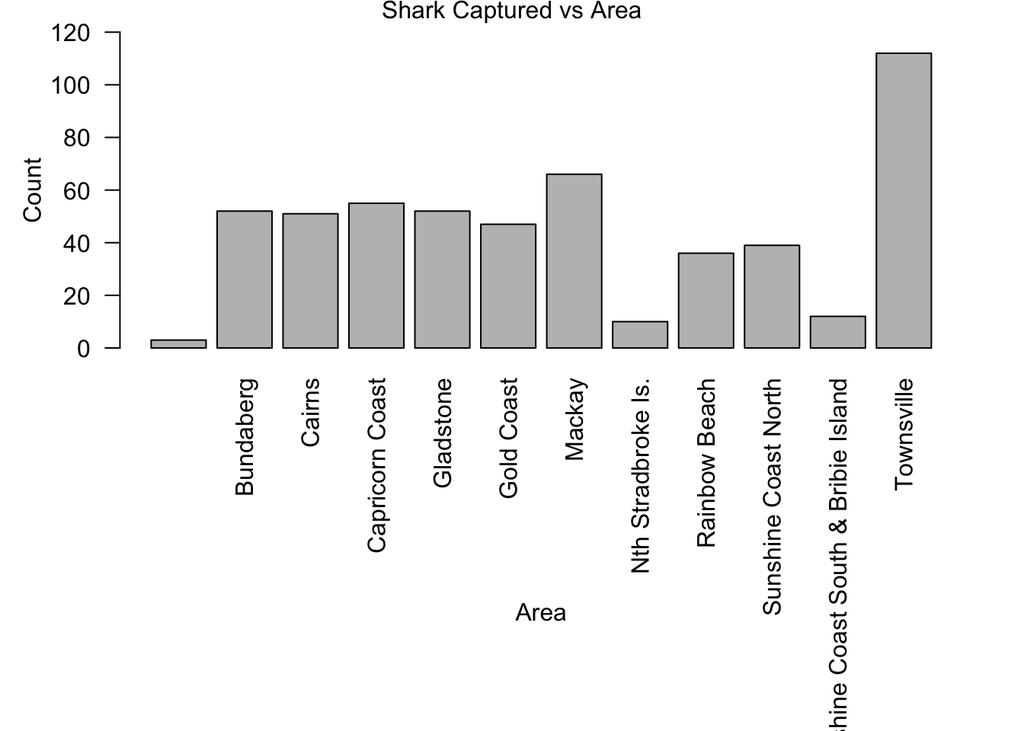

```r
Area.freq = table(Area)
op <- par(mar = c(13,4,1,2) + 0.1)
barplot(Area.freq, las=2, main="Shark captured vs Area", xlab="Area", ylab = "Count",ann=FALSE,120, beside=TRUE, ylim=range(pretty(c(0, 120))))
mtext("Shark Captured vs Area",side=3,line=-0.8, outer=TRUE)
mtext("Count", side=2, line=2.5)
mtext("Area", side=1, line=8.5)
```

The bar plot illustrates the amount of sharks caught with respect to the area in which they were caught in 2016. Results illustrate that Townsville had the highest amount of sharks caught with 112 and the lowest being North Stradbroke Island- 10. This information is useful to the Queensland Shark Control program since it tells them which areas are the most prone to shark attacks.

Whilst there is no evidence that a increase in shark population is directly related to the amount of shark attack - supported by a 2010 study conducted by John G. West ‘Changing patterns of shark attacks in Australian waters’[2], it states that there are various factors which affect the frequency of shark attacks, one being an increase of human population.Subsequently, this leads the amount of activities near that area increasing, which increases the likelihood of a shark encounter. Thus, an increase of shark concentration coupled with a rise in human activities will greatly increase the chances of shark attacks. Shark Control Programs need to be implemented to minimise this risk. Additional precautions such as educating the general public of this issue and implementing shark lines along the bay is highly recommended.

A limitation to this study is that it does not specify a precise location along the area in which the shark captured, providing no insight on whether the sharks are more concentrated closer to the beach or further out.

To this day, there has not been a direct relation established between a specific variable and a direct increase in the likelihood of shark attacks, however with an increasing population and a high concentration of sharks the possibility of an encounter between a human and a shark becomes more likely.

## 3.2 Conclusion

To mitigate the risk of shark-human related incidents the Shark Control Program aim to focus on Townsville where the greatest concentration of sharks lie.

# 4 Research Question 2

**Question:** Does Length of sharks affect how aggressive it is and its likelihood of capture?

**Null Hypothesis:** Smaller sharks (2.1m) are more aggressive and will have a higher capture rate

**Alternate Hypothesis** Smaller sharks are not more aggressive and the length of the shark has no effect on its likelihood of capture

## 4.1 Results of Research Question 2

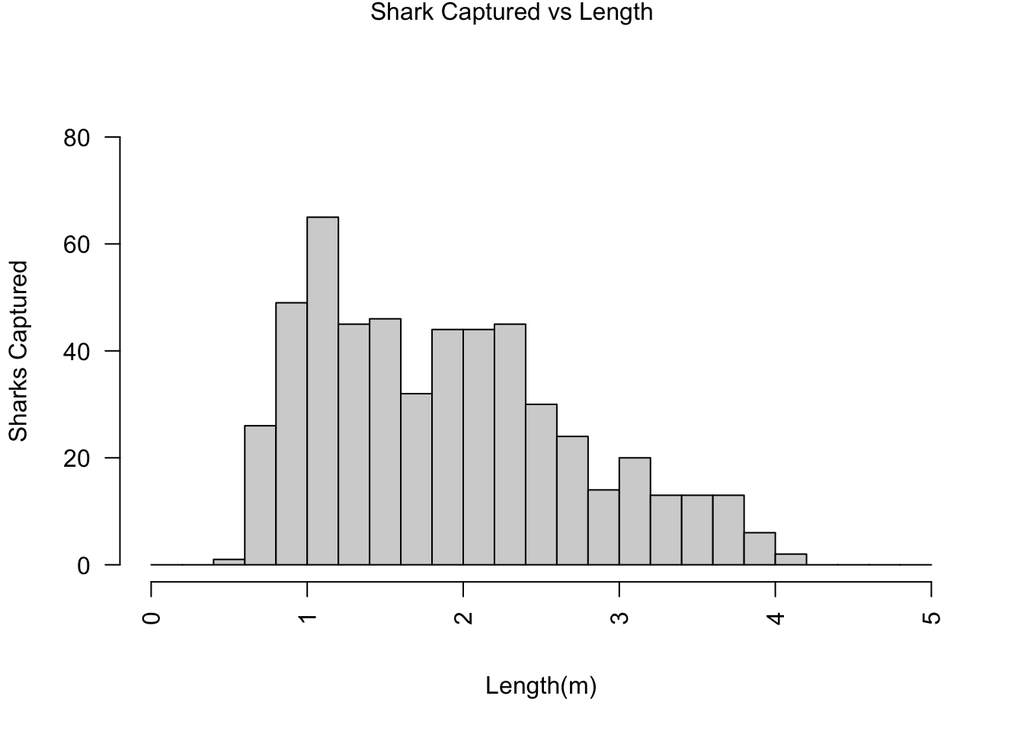

```r
hist(data$Length..m., las=2, main="Shark Numbers", xlab = "Length", ylab = "Number of sharks Captured", ann=FALSE, xlim = c(0,5), ylim = c(0,80),breaks=seq(0,5,0.2))
mtext("Sharks Captured", side=2, line=3)
mtext("Shark Captured vs Length", side = 3, line = -0.87, outer = TRUE)
mtext("Length(m)", side=1, line=3)
```

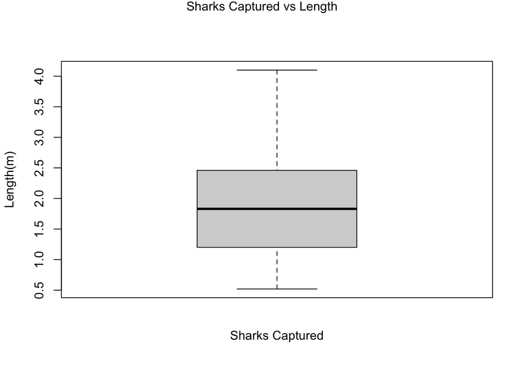

```r
boxplot(data$Length..m.)
mtext("Length(m)", side=2, line=3)
mtext("Sharks Captured vs Length", side = 3, line = -0.9, outer = TRUE)
mtext("Sharks Captured", side=1, line=2)
```

```r
p = (mean(data$Length..m.)-1.92)/(sd(data$Length..m.)/sqrt(532))

2*(1-pt(abs(p),532))
```

```
## [1] NA
```

# 5 References (if needed)

Style: APA

[1]Shark Control Program Shark Catch Statistics by year - 2001–2016 - Shark Control Program catch statistics - Open Data Portal | Queensland Government. (2016). Retrieved November 14, 2020, from Qld.gov.au website: https://www.data.qld.gov.au/dataset/shark-control-program-shark-catch-statistics/resource/5c6be990-3938-4125-8cca-dac0cd734263

[2] West, J. G. (2011). Changing patterns of shark attacks in Australian waters. Marine and Freshwater Research, 62(6), 744. https://doi.org/10.1071/mf10181